# Projeto de Capacidade Produtiva- Fase II

Allan B. Martins

23 maio 2022

# Técnica utilizada para criação dos Modelos de Análise Envoltória de Dados (DEA) - 2021 JAN e DEZ -

Contextualização

A Metodologia DEA (Data Envelopment Analysis)

O primeiro modelo DEA foi proposto por Charnes, Coooper e Rhodes (1978) que, a seu tributo, se designou DEA – CCR, tinha orientação ao input e pressupunha a existência de retornos constantes de escala (CRS). Esta metodologia procura estabelecer quais as empresas, de uma dada amostra, determinam a superfície envolvente ou fronteira de produção eficiente.

A metodologia DEA é aplicada na avaliação unitária de unidades homogéneas ou empresas, tais como hotéis. A unidade em avaliação é normalmente denominada como uma unidade de tomada de decisão (DMU, Data Managment Unit) que converte inputs em outputs, facto pelo qual em qualquer estudo a sua identificação é um aspeto difícil e crucial. Segundo DEA, o desempenho de uma empresa é avaliado em relação a uma fronteira eficiente, que é construída através da combinação linear das empresas existentes. O procedimento baseia-se numa formulação matemática sofisticada.

Usaremos a função “deaR” desse pacote e seus padrões (default), com seu conjunto de funções para Análise de Envoltório de Dados. Ele executa modelos DEA clássicos e difusos

# 1 Etapa I - Estruturação do banco de dados

## 1.1 Universo Estatístico

```
## Rows: 26
## Columns: 4
## $ uf                      <chr> "AC", "AP", "RO", "RR", "TO", "AL", "CE", "GO"~
## $ x1_ft_2021              <dbl> 38.00, 39.00, 66.00, 51.00, 90.00, 110.25, 208~
## $ x2_cust_2021_jan_dez    <dbl> 209120.7, 182444.2, 684196.8, 199142.3, 870971~
## $ y_ubp_real_2021_jan_dez <dbl> 24231.81, 10367.49, 44148.79, 18509.69, 35436.~
```

## 1.2 Tabela de dados

| UF | Força 2021 | Custeio Exec. | UBP Real |
| --- | --- | --- | --- |
| AC | 38.00 | 209120.7 | 24231.81 |
| AP | 39.00 | 182444.2 | 10367.49 |
| RO | 66.00 | 684196.8 | 44148.79 |
| RR | 51.00 | 199142.3 | 18509.69 |
| TO | 90.00 | 870971.6 | 35436.92 |
| AL | 110.25 | 253311.2 | 98888.85 |
| CE | 208.00 | 1045236.7 | 123119.82 |
| GO | 175.00 | 945441.9 | 73607.82 |
| PA | 81.75 | 1661962.3 | 103707.52 |
| PI | 95.25 | 1658021.1 | 44245.87 |
| RN | 102.00 | 407703.6 | 48770.03 |
| SE | 90.75 | 689435.5 | 70829.22 |
| AM | 102.00 | 1066132.2 | 82726.70 |
| ES | 79.00 | 1338648.3 | 92580.25 |
| MA | 100.50 | 733066.4 | 79673.41 |
| MS | 93.00 | 915932.3 | 97619.28 |
| MT | 122.25 | 3272093.1 | 180178.14 |
| RS | 157.00 | 2352366.1 | 159850.55 |
| BA | 331.00 | 4587625.9 | 228726.35 |
| MG | 221.00 | 3770419.5 | 452079.09 |
| PB | 86.00 | 854354.1 | 178570.96 |
| PE | 105.75 | 1160214.6 | 150363.51 |
| PR | 232.00 | 3174426.5 | 267542.77 |
| RJ | 402.00 | 4069715.6 | 332225.96 |
| SC | 203.00 | 2328359.8 | 264710.38 |
| SP | 898.00 | 12703164.8 | 946330.14 |

# 2 Etapa II - Identificação de Outliers

## 2.1 Gráfico de barra para visualização de outliers

[figure not shown]

## 2.2 Gráfico de dispersão para visualização de outliers

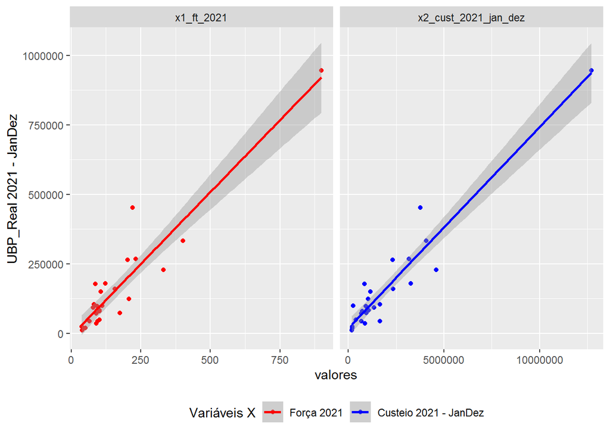

# 3 Etapa III - Geração Modelos de Análise Envoltória de Dados (DEA) - 2021 JAN e DEZ -

Contextualização

A Metodologia DEA (Data Envelopment Analysis)

A metodologia DEA é aplicada na avaliação unitária de unidades homogéneas ou empresas, tais como hotéis. A unidade em avaliação é normalmente denominada como uma unidade de tomada de decisão (DMU, Data Managment Unit) que converte inputs em outputs, facto pelo qual em qualquer estudo a sua identificação é um aspeto difícil e crucial. Segundo DEA, o desempenho de uma empresa é avaliado em relação a uma fronteira eficiente, que é construída através da combinação linear das empresas existentes. O procedimento baseia-se numa formulação matemática sofisticada.

Usaremos a função “deaR” desse pacote e seus padrões (default), com seu conjunto de funções para Análise de Envoltório de Dados. Ele executa modelos DEA clássicos e difusos

## 3.1 Resultados de eficiência

```
##      AC      AP      RO      RR      TO      AL      CE      GO      PA      PI
## 0.45809 0.21021 0.32215 0.31693 0.19332 1.00000 0.44903 0.30557 0.61096 0.22372
##      RN      SE      AM      ES      MA      MS      MT      RS      BA      MG
## 0.41239 0.45498 0.39060 0.56439 0.47510 0.50876 0.70981 0.49035 0.33279 0.98517
##      PB      PE      PR      RJ      SC      SP
## 1.00000 0.68478 0.55538 0.39801 0.62800 0.50752
```

## 3.2 Gráfico de barra

Percentual de aproximação com a fronteira de eficiência 100% nos estados da RBMLQ-I

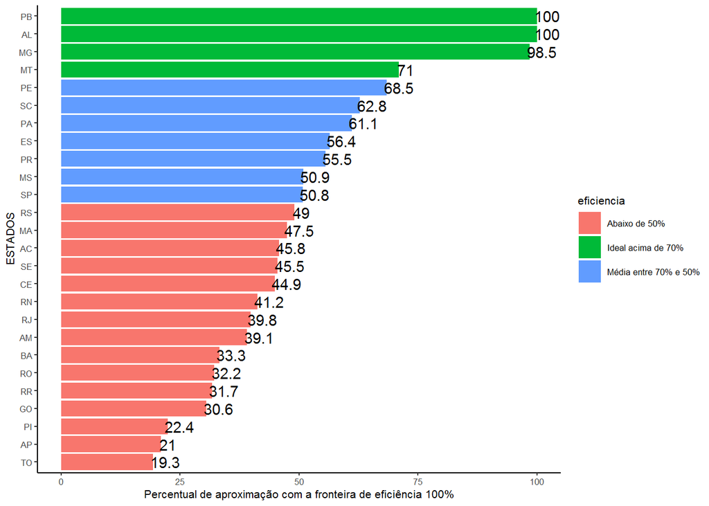

# 4 Diversos

## 4.1 Créditos - Participantes do Projeto Capacidade Produtiva:

**MEMBROS DO PROJETO**  
Allan Batista Martins,  
##

## 4.2 Material de Apoio

- Tutorial - Data Envelopment Analysis with deaR:
- Tratamento de Outliers (Bacon) - R na Pesquisa Contábil: [Alessanderson Jacó de Carvalho](https://youtu.be/hfO5LLbRioY)
- PLAYLIST - R na Pesquisa Contábil (Parte 1 ao 20):
- Utilização da metodologia DEA (Data Envelopment Analysis) para avaliar o impacto das TIC sobre a produtividade na indústria da hospitalidade:
- PLAYLIST - Criando gráficos no R com o ggplot2 (Parte 1 ao 2): [Fernanda Peres](https://youtu.be/DYsPRa3vpf0)
- PLAYLIST - R Markdown: Gerando relatórios usando o R (Parte 1 ao 5): [Fernanda Peres](https://youtu.be/obxa5VH4WvY)
- Minicurso R - UFPR: [UFPR](https://youtu.be/obxa5VH4WvY)
- R Markdown: The Definitive Guide: [Yihui Xie, J. J. Allaire, Garrett Grolemund](https://bookdown.org/yihui/rmarkdown/)